# Numerical data

Ariana Fairbanks

August 28 2018

1.0

### Functions introduced in this module:

`mean`, `sd`, `var`, `median`, `sort`, `IQR`, `quantile`, `summary`, `min`, `max`, `favstats`, `ggplot`, `geom_histogram`, `geom_point`, `labs`

## Introduction

In this module, we’ll learn about numerical data and how to summarize it through summary statistics and graphs.

## Load packages

We load the `mosaic` package as well as the `MASS` package so that we can work with data on risk factors associated with low birth weight.

```r
library(MASS)
library(mosaic)
```

## A note about mathematical notation

From time to time, we will use mathematical notation that can’t be typed directly on the keyboard. For example, let’s suppose we want to typeset the quadratic formula, which involves a complicated fraction as well as a square root symbol.

When such notation appears, it will be surrounded by double dollar signs as follows:

$$x = \frac{-b \pm \sqrt{b^{2} - 4ac}}{2a}$$

The R Notebook will interpret this special mathematical notation and render it on the screen as well as in the HTML document.[^1] If the nicely formatted formula does not appear on your screen, place your cursor anywhere inside the math formula and hit Ctrl-Enter or Cmd-Enter (PC or Mac respectively).

Sometimes, we want such math to appear inline. We can do this with single dollar signs. For example, the distance formula is $d = \sqrt{(x_{2} - x_{1})^{2} + (y_{2} - y_{1})^{2}}$, a fact you may have learned a long time ago.

This will *not* render visually in the R Notebook, but it will show up in the HTML file. If you want to check that it worked properly without having to preview the HTML, you can either hover your cursor over the math formula and wait a second, or you can place your cursor anywhere inside the math formula and hit Ctrl-Enter or Cmd-Enter (PC or Mac respectively) to see a pop-up window previewing the mathematical content properly formatted.

You will be shown examples of any mathematical notation you need to use in any given module, so feel free to copy/paste/modify any math notation you need.

## Mean and standard deviation

Summary statistics come in two general flavors: measures of center and measures of spread.

The first pair we’ll consider is the mean and the standard deviation. The *mean*—denoted $\bar{y}$—of a variable $y$ is calculated by summing all the values of the variable, and dividing by the total number of observations. In formula form, this is

$$\bar{y} = \frac{\sum y}{n}.$$

This is a measure of center since it estimates the “middle” of a set of numbers. It is calculated in R using the `mean` command.

Throughout this module, we will be using the `birthwt` data set. Go to the Console and type `?birthwt` to see the help file for this data. (If you’re looking at the R Notebook, you’ll see that the command in the previous sentence is enclosed in backticks. This is only for formatting in the R Notebook; you won’t type the backticks at the Console.)

If we want to calculate the mean weight in pounds of the mother at the last menstrual period, we type the following:

```r
mean(birthwt$lwt)
```

```
[1] 129.8148
```

The corresponding measure of spread is the *standard deviation*. Usually this is called $s$ and is calculated using a much more complicated formula:

$$s = \sqrt{\frac{\sum (y - \bar{y})^2}{n - 1}}.$$

This is a measure of spread because the $(y - \bar{y})$ term measures the how far away each data point is from the mean.

In R, this is calculated with the `sd` command.

```r
sd(birthwt$lwt)
```

```
[1] 30.57938
```

The mean and the standard deviation should always be reported together.

Another related measurement is the *variance*, but this is nothing more than the standard deviation squared:

$$s^2 = \frac{\sum (y - \bar{y})^2}{n - 1}.$$

(Compare this formula to the one for the standard deviation. Nothing has changed except for the removal of the square root.) We rarely use the variance in an introductory stats class because it’s not as interpretable as the standard deviation.[^2] If you need to do this in R, the command is `var`.

```r
var(birthwt$lwt)
```

```
[1] 935.0985
```

(You can check and see that the number above really is just 30.5793804 squared. Remember, in the R Notebook, you can click inside the inline R code chunk from the previous sentence and hit Ctrl-Enter or Cmd-Enter.)

## Median and IQR

Another choice for measuring the center and spread of a data set is the median and the IQR. The median is just the middle value if the list of values is ordered. In R, it is calculated using the `median` command.

```r
median(birthwt$lwt)
```

```
[1] 121
```

You can check that this is correct: if we print out the entire `lwt` variable, you can see all 189 values, and if we’re clever about it, we can see them in order using the `sort` command.

```r
sort(birthwt$lwt)
```

```
  [1]  80  85  85  89  90  90  90  91  92  94  95  95  95  95
 [15]  95  95  96  97  98 100 100 100 100 100 101 102 102 103
 [29] 103 103 105 105 105 105 105 105 105 107 107 108 109 109
 [43] 110 110 110 110 110 110 110 110 110 110 110 112 112 112
 [57] 112 113 113 113 115 115 115 115 115 115 115 116 117 117
 [71] 118 118 119 119 119 120 120 120 120 120 120 120 120 120
 [85] 120 120 120 120 120 120 120 120 121 121 121 121 122 122
 [99] 123 123 123 124 124 125 125 125 127 128 128 129 130 130
[113] 130 130 130 130 130 130 130 130 130 130 130 131 132 132
[127] 132 133 133 134 134 134 135 135 135 135 137 138 138 140
[141] 140 140 141 142 142 147 147 148 150 150 150 150 150 153
[155] 154 154 155 155 155 158 158 160 160 165 167 168 169 169
[169] 170 170 170 170 175 182 184 185 186 187 187 189 190 190
[183] 200 202 215 229 235 241 250
```

##### Exercise 1

If there are 189 mothers in this data set, in which position in the list will the median value appear? (Be careful: you can’t just divide 189 by 2, although if you do, you’ll be close to the right answer.) Verify that the median value 121 does appear in the position you calculated.

95

Calculating the *interquartile range*—or *IQR*—requires first the calculation of the first and third quartiles, denoted Q1 and Q3. If the median is the 50% mark in the sorted data, the first and third quartiles are the 25% and the 75% marks, respectively.[^3] Then the IQR is just

$$IQR = Q3 - Q1$$

In R, you can get the IQR by using—are you ready for this?—the `IQR` command.

```r
IQR(birthwt$lwt)
```

```
[1] 30
```

The IQR is a measure of spread because the distance between Q1 and Q3 measures the span of the “middle 50%” of the data.

##### Exercise 2

A general function for computing any percentile in R is the `quantile` function. For example, since Q1 is the 25th percentile, you can compute it as follows:

```r
Q1 <- quantile(birthwt$lwt, 0.25)
unname(Q1)
```

```
[1] 110
```

(The `unname` command just helps clean up the output here. Don’t worry too much about it.)

Now compute Q3. Also check that the IQR calculated above matches the value you get from subtracting Q3 minus Q1.

```r
Q3 <- quantile(birthwt$lwt, 0.75)
unname(Q3)
```

```
[1] 140
```

```r
Q3 - Q1
```

```
75%
 30
```

The median and the IQR should always be reported together.

## Robust statistics

Some statistics are more sensitive than others to features of the data. For example, outliers are data points that are far away from the bulk of the data. The mean and especially the standard deviation can change a lot when outliers are present. Also, skewness in the data frequently pulls the mean too far in the direction of the skew while simultaneously inflating the standard deviation.

On the other hand, the median and IQR are “robust”, meaning that they do not change much (or at all) in the presence of outliers and they tend to be good summaries even for skewed data.

##### Exercise 3

Explain why the median and IQR are robust. In other words, why does an outlier have little or no influence on the median and IQR?

Because rather than summing up the data before interpreting it looking at the median or the IQR looks at the data at specific points. Because of this, it doesn’t matter much if you have a few values that are much, much larger or smaller than the rest because it has little effect on the positioning of the rest of the data.

## Five-number summary

A *five-number summary* is the minimum, Q1, median, Q3, and maximum of a set of numbers.

The `summary` command in R gives you the five-number summary, and throws in the mean for good measure.

```r
summary(birthwt$lwt)
```

```
   Min. 1st Qu.  Median    Mean 3rd Qu.    Max.
   80.0   110.0   121.0   129.8   140.0   250.0
```

You can, of course, isolate the various pieces of this. You already know most of the commands below.

```r
min(birthwt$lwt)
```

```
[1] 80
```

```r
median(birthwt$lwt)
```

```
[1] 121
```

```r
max(birthwt$lwt)
```

```
[1] 250
```

```r
mean(birthwt$lwt)
```

```
[1] 129.8148
```

```r
quantile(birthwt$lwt)
```

```
  0%  25%  50%  75% 100%
  80  110  121  140  250
```

##### Exercise 4

What is the difference between the way `quantile` was used in a previous exercise versus the way it was used here? How did that change the output?

This time we used the command without an additional positioning parameter, so it gave us it’s default output, which consists of the most commonly used quartiles. We can specify the quartile we want by passing it as a decimal parameter like before.

The `mosaic` package also has a summary command called `favstats` that has a little more information, including the standard deviation, the sample size, and a count of any cases that are missing data. This command is much more useful than the standard `summary` command.

```r
favstats(birthwt$lwt)
```

|  | min | Q1 | median | Q3 | max | mean | sd | n | missing |
| --- | --- | --- | --- | --- | --- | --- | --- | --- | --- |
|  | 80 | 110 | 121 | 140 | 250 | 129.8148 | 30.57938 | 189 | 0 |

Also, don’t forget about the trick for using R commands inline. If you need to mention a statistic in the middle of a sentence, there is no need to break the sentence and display a code chunk. Be sure you’re looking at the R Notebook (not the HTML file) to note that the numbers in the next sentence are not manually entered, but are calculated on the fly:

There are 189 births represented in this data and the median weight of the women as of their last menstrual period is 121 pounds.

##### Exercise 5

Type a full, contextually meaningful sentence using inline R code (as above, but changing the commands) reporting the minimum and maximum baby weights (in grams) in our data set.

In this data set the minimum baby weight in grams is 709 and the maximum baby weight in grams is 4990.

## Summary statistics by group

Using base R, it’s not so easy to get summary statistics for each group separately. Fortunately, the `mosaic` package comes to the rescue, allowing for more flexibility.

For example:

```r
favstats(lwt ~ race, data = birthwt)
```

| race | min | Q1 | median | Q3 | max | mean | sd | n | missing |
| --- | --- | --- | --- | --- | --- | --- | --- | --- | --- |
| 1 | 90 | 112 | 129.5 | 143.25 | 235 | 132.0521 | 29.09381 | 96 | 0 |
| 2 | 98 | 120 | 129.0 | 179.00 | 241 | 146.8077 | 39.63939 | 26 | 0 |
| 3 | 80 | 105 | 119.0 | 130.00 | 250 | 120.0149 | 25.13026 | 67 | 0 |

The notation is a little weird. Don’t worry about the tilde for now. Just learn that it needs to be there. This says, “Look at the numerical variable `lwt` grouped by `race`.” Indeed, the output has three lines, one for each racial group in the data. This extended notation works for lots of commands, like `mean`, `sd`, `median`, `IQR`, `quantile`, etc. as long as the `mosaic` package is loaded.

##### Exercise 6

Choose one numerical variable and one categorical variable from the `birthwt` data set. Find the five-number summary of your numerical variable grouped by your categorical variable.

```r
favstats(ptl ~ age, data = birthwt)
```

| age | min | Q1 | median | Q3 | max | mean | sd | n | missing |
| --- | --- | --- | --- | --- | --- | --- | --- | --- | --- |
| 14 | 0 | 0 | 0 | 0.5 | 1 | 0.33333333 | 0.5773503 | 3 | 0 |
| 15 | 0 | 0 | 0 | 0.0 | 0 | 0.00000000 | 0.0000000 | 3 | 0 |
| 16 | 0 | 0 | 0 | 0.0 | 0 | 0.00000000 | 0.0000000 | 7 | 0 |
| 17 | 0 | 0 | 0 | 0.0 | 1 | 0.08333333 | 0.2886751 | 12 | 0 |
| 18 | 0 | 0 | 0 | 0.0 | 1 | 0.10000000 | 0.3162278 | 10 | 0 |
| 19 | 0 | 0 | 0 | 0.0 | 2 | 0.12500000 | 0.5000000 | 16 | 0 |
| 20 | 0 | 0 | 0 | 0.0 | 2 | 0.22222222 | 0.5483189 | 18 | 0 |
| 21 | 0 | 0 | 0 | 0.0 | 1 | 0.08333333 | 0.2886751 | 12 | 0 |
| 22 | 0 | 0 | 0 | 0.0 | 2 | 0.30769231 | 0.6304252 | 13 | 0 |
| 23 | 0 | 0 | 0 | 0.0 | 1 | 0.07692308 | 0.2773501 | 13 | 0 |

[output cut: 14 more lines]

## ggplot

The `ggplot` command is an all-purpose graphing utility. It uses a graphing philosophy derived from a book called *The Grammar of Graphics* by Leland Wilkinson. The basic idea is that each variable you want to plot should correspond to some element or “aesthetic” component of the graph. The obvious places for data to go are along the y-axis or x-axis, but other aesthetics are important too; graphs often use color, shape, or size to illustrate different aspects of data. Once these aesthetics have been defined, we will add “layers” to the graph. These are objects like dots, boxes, lines, or bars that dictate the type of graph we want to see.

In an introductory course, we won’t get too fancy with these graphs. But be aware that there’s a whole field of data visualization that studies clear and interesting ways to understand data graphically.

It will be easier to explain the `ggplot` syntax in the context of specific graph types, so let’s proceed to the next section and start looking at ways to graph numerical data.

## Graphing one numerical variable

From the birth weight data `birthwt`, let’s consider the weight of the mother at her last menstrual period. This is clearly a numerical variable.

The single most useful display of a single numerical variable is a histogram. Here is the `ggplot` command to do that:

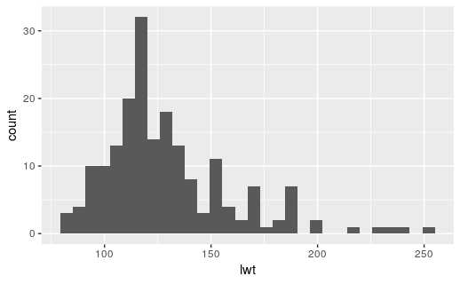

```r
ggplot(birthwt, aes(x = lwt)) +
    geom_histogram()
```

Let’s walk through this syntax step by step. The first argument of the `ggplot` command is the name of the data frame, in this case, `birthwt`. Next we define the aesthetics using `aes` and parentheses. Inside the parentheses, we assign any variables we want to plot to aesthetics of the graph. For this analysis, we are only interested in the variable `lwt` and for a histogram, the numerical variable typically goes on the x-axis. That’s why it says `x = lwt` inside the `aes` argument. Next, `ggplot` needs to know what kind of graph we want. Graph types are called “geoms” in the `ggplot` world, and `geom_histogram()` tells `ggplot` to add a histogram layer. (Adding a layer is accomplished by literally typing a plus sign.)

## Binwidths and boundaries

It’s also easier to interpret the histogram when the bins’ edges line up with numbers that are easy to see in the plot. Use `boundary` to determine where you want one of the bin boundaries to fall. For example, if we set the boundary to 100, that means that one bar will start with its left edge at 100. The latter number is pretty arbitrary; once one boundary is set, it determines where all the other bins will line up. With a binwidth of 10, we’d get the same graph if the boundary were set to 110 or 150, or any other multiple of 10.

We use `binwidth` and `boundary` inside the parentheses of the `geom_histogram` to modify these parameters.

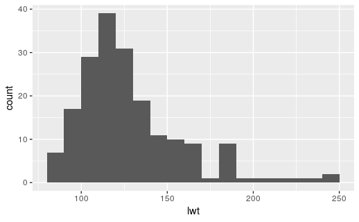

```r
ggplot(birthwt, aes(x = lwt)) +
    geom_histogram(binwidth = 10, boundary = 100)
```

##### Exercise 7

Write a paragraph or so describing the shape of the distribution of the `lwt` variable, focusing on the three key features (modes, symmetry, and outliers). Be sure to speak about these in the context of the data; in other words, your answer should refer to women and their weight, and not just abstract numbers and stats words.

##### Exercise 8

Create a histogram of the baby’s birth weight (in grams). Adjust the binwidth and boundary to see the shape of the distribution more clearly. Then describe the shape of the distribution as you did for the `lwt` variable above.

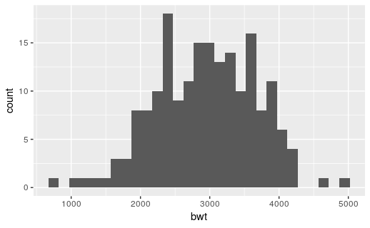

```r
ggplot(birthwt, aes(x = bwt)) + geom_histogram(binwidth = 150, boundary = 70)
```

Seems to be unimodal and is mostly symmetrical. There are possible outliers on each side.

##### Exercise 9(a)

The `faithful` data set has a variable called `waiting` that records the waiting times (in minutes) between eruptions of the Old Faithful geyser in Yellowstone National Park.

Here is a histogram of those eruptions.

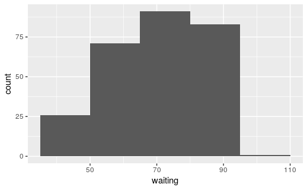

```r
ggplot(faithful, aes(x = waiting)) +
    geom_histogram(binwidth = 15, boundary = 50)
```

Write a paragraph or so describing the shape of the distribution of waiting times, focusing on the three key features (modes, symmetry, and outliers).

This is a trick question! Old Faithful is actually bimodal. It has two eruption durations followed by different waiting times.

##### Exercise 9(b)

Change the binwidth (no need to change the boundary) to something more sensible to see the bimodal nature of the distribution.

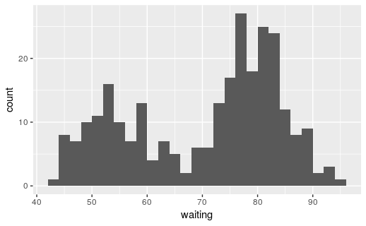

```r
ggplot(faithful, aes(x = waiting)) +
    geom_histogram(binwidth = 2, boundary = 10)
```

## Less useful plot types

There are two other graph types that one might see for a single numerical variable: dotplots and boxplots. I’m not a big fan of dotplots as they are just a messier version of histograms. I do like boxplots, but they are typically less informative than histograms. Boxplots are much better for comparing groups, so we’ll see them in another module. Besides, there isn’t an easy way to make a boxplot for a single numerical variable using `ggplot`.

## Graphing two numerical variables

The proper graph for two numerical variables is a scatterplot. We graph the response variable on the y-axis and the explanatory variable on the x-axis.

##### Exercise 10(a)

If you were interested in exploring a possible association between the weight of the mother at her last menstrual period and the birth weight of the baby, which variable would you consider to be the response variable and which would be the explanatory variable? Explain your reasoning. Be careful not to use language that suggests cause or effect. There may, in fact, be a causal relationship, but that is not going to be proven from observational data. Instead, when there is an association, we say that the explanatory variable might be used to “predict” the value of the response variable.

I would expect the birth weight of the mother to be the explanitory variable and the birth weight of the baby to be responsive. The baby didn’t yet exist at the time the mother was weighed, so it stands to reason that it is the mother’s weight that might be predictive of the child’s.

Now we’ll create a scatterplot of the birth weight of the baby and the weight of the mother at her last menstrual period. Since we are plotting two variables, we have two aesthetics, one on the y-axis (the response variable) and one on the x-axis (the explanatory variable). Since scatterplots use points to plot each data value, the correct layer to add is `geom_point()`.

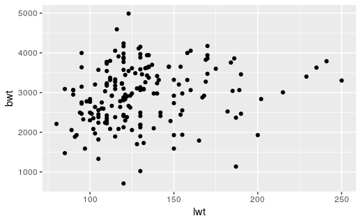

```r
ggplot(birthwt, aes(y = bwt, x = lwt)) +
    geom_point()
```

##### Exercise 10(b)

Comment on the nature of the association. (Is is positive/negative, or are these two variables independent?) As always, be sure to word your answer in the context of the data.

There seems to be some positive correlation between the weight of the mother and the weight of the child.

##### Exercise 11(a)

Consider the two variables `bwt` and `age`. Which variables would you consider as response and explanatory?

Once again, as it’s the mother who has the child I would consider the mother’s age to be potentially predictive and the weight of the child to be potentially responsive.

##### Exercise 11(b)

Now create a scatterplot to visualize the relationship between the birth weight of the baby and the mother’s age. Be careful to make sure you put the variables on the right axes!

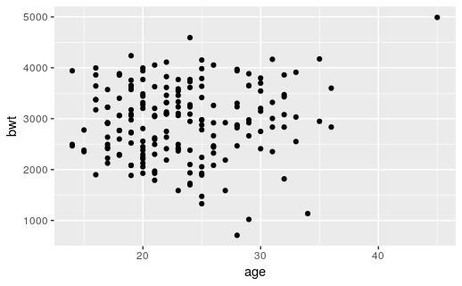

```r
ggplot(birthwt, aes(y = bwt, x = age)) +
    geom_point()
```

##### Exercise 11(c)

Now comment on the nature of the association.

There doesn’t seem to be much of a correlation either way.

## Publication-ready graphics

The great thing about `ggplot2` graphics is that they are already quite pretty. To take them from exploratory data analysis to the next level, there are a few things we can do to tidy them up.

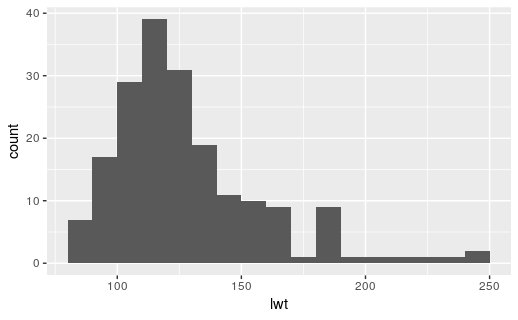

```r
ggplot(birthwt, aes(x = lwt)) +
    geom_histogram(binwidth = 10, boundary = 100)
```

Note that the variable names of this data set are not terribly informative. In other words, if you were using this graph in a publication or presentation for an audience, they would have no idea what `lwt` was. Also note that this graph could use a title. We can do all this with `labs` (for labels). Observe:

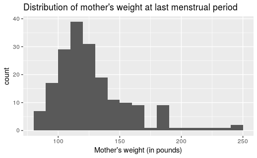

```r
ggplot(birthwt, aes(x = lwt)) +
    geom_histogram(binwidth = 10, boundary = 100) +
    labs(title = "Distribution of mother's weight at last menstrual period",
         x = "Mother's weight (in pounds)")
```

You can also see that we took the opportunity to mention the units of measurement (pounds) for our variable in the x-axis label. This is good practice.

A quick note about formatting in R code chunks. Notice that I put different parts of the last `ggplot` command on their own separate lines. The command would still work if I did this:

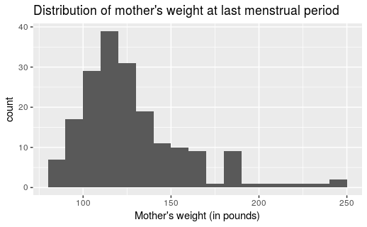

```r
ggplot(birthwt, aes(x = lwt)) + geom_histogram(binwidth = 10, boundary = 100) + labs(title = "Distribution of mother's weight at last menstrual period", x = "Mother's weight (in pounds)")
```

But it’s much harder to read. If you find that your code is “wrapping” to the next line, find some spots like commas or plus signs to break the code. Be sure to break the line after the comma or plus sign.

##### Exercise 12

Modify the following scatterplot by adding a title and labels for both the y-axis and x-axis.

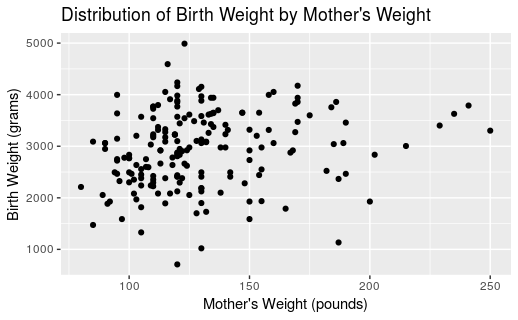

```r
# Modify the following scatterplot by adding a title and
# labels for both the y-axis and x-axis.
ggplot(birthwt, aes(y = bwt, x = lwt)) +
    geom_point() + labs(title = "Distribution of Birth Weight by Mother's Weight", x = "Mother's Weight (pounds)", y = "Birth Weight (grams)")
```

Every part of the graph can be customized, from the color scheme to the tick marks on the axes, to the major and minor grid lines that appear on the background. We won’t go into all that, but you can look at the [ggplot2 documentation](http://ggplot2.tidyverse.org/) online and search Google for examples if you want to dig in and figure out how to do some of that stuff. However, the default options are often (but not always) the best, so be careful that your messing around doesn’t inadvertently make the graph less clear or less appealing.

## Conclusion

Summary statistics are simple numbers that describe and summarize data sets. Measures of center tell us where the “middle” of our data lies, and measures of spread tell us how spread out our data is. These measures should always be reported in pairs, for example the mean/standard deviation, or the median/IQR. Sometimes it can be useful to report summary statistics with the data separated by a categorical grouping variable.

The `ggplot2` package with its `ggplot` command is a very versatile tool for creating nice graphs relatively easily. For a single numerical variable, the standard graph type is a histogram. For two numerical variables, use a scatterplot.

[^1]: This notation is part of a mathematical document preparation system called LaTeX, pronounced “Lay-tek” (not like the rubbery substance).
[^2]: The main reason for this is units. If the data variable is the mother’s weight in pounds, then both the mean and the standard deviation are also reported in pounds. The variance has units of “pounds squared”, but what does that even mean?
[^3]: One way to compute these is to calculate the median of the lower and upper halves of the data separately. Then again, it’s hard to know how to split the data set into halves if there are an odd number of observations. There are many different methods for computing percentiles in general, but you don’t need to worry too much about the particular implementation in R.